# A history of rationality in economics

A computational approach

Thomas Delcey

Thomas.delcey@ube.fr

Université de Bourgogne

Aurélien Goutsmedt

aurelien.goutsmedt@uclouvain.be

UC Louvain; ICHEC

Alexandre Truc

Alexandre.truc[at]auCNRSpointFr

Université Côte d’Azur

## Context

- **Special issue**: methods in the history of economic thought (HET)
- **Goal**: contribute a methodological essay showing how quantitative tools can enrich history of economic thought
- **Neither a proof of concept paper, nor a review of methods**

## Our contribution

- The meanings of rationality in 20<sup>th</sup>-century economics:
  - A long-standing concern for historians
  - Using computational methods to capture the broader picture
- A concrete methodological reflection based on our workflow:
  - Challenges, successes, limits, and possible improvements

## From sources to corpus

- Our main source: JSTOR fulltext database (around 300 000 documents, 31 millions sentences).

**It is sometimes more challenging to build the data than to analyze it:**

- Access to the source (JSTOR Data for Research).
- Filtering documents (book reviews).
- Cleaning texts (headers, acknowledgments, etc.).
- Matching datasets (JSTOR + WoS).
- Handling large datasets.

Figure 1: Distribution of documents in the JSTOR fulltext database

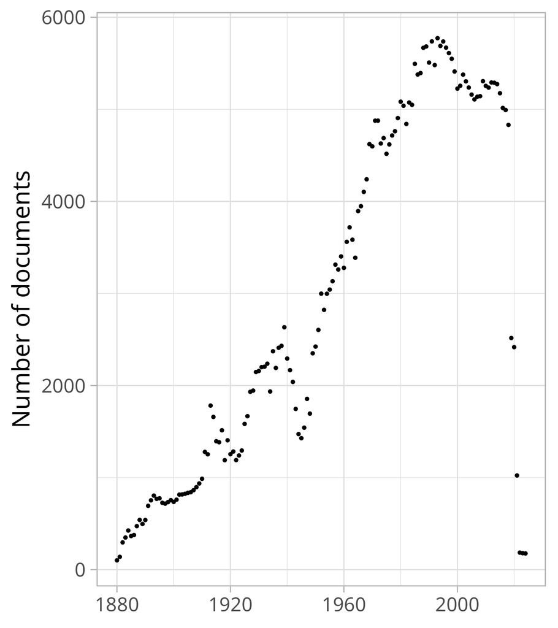

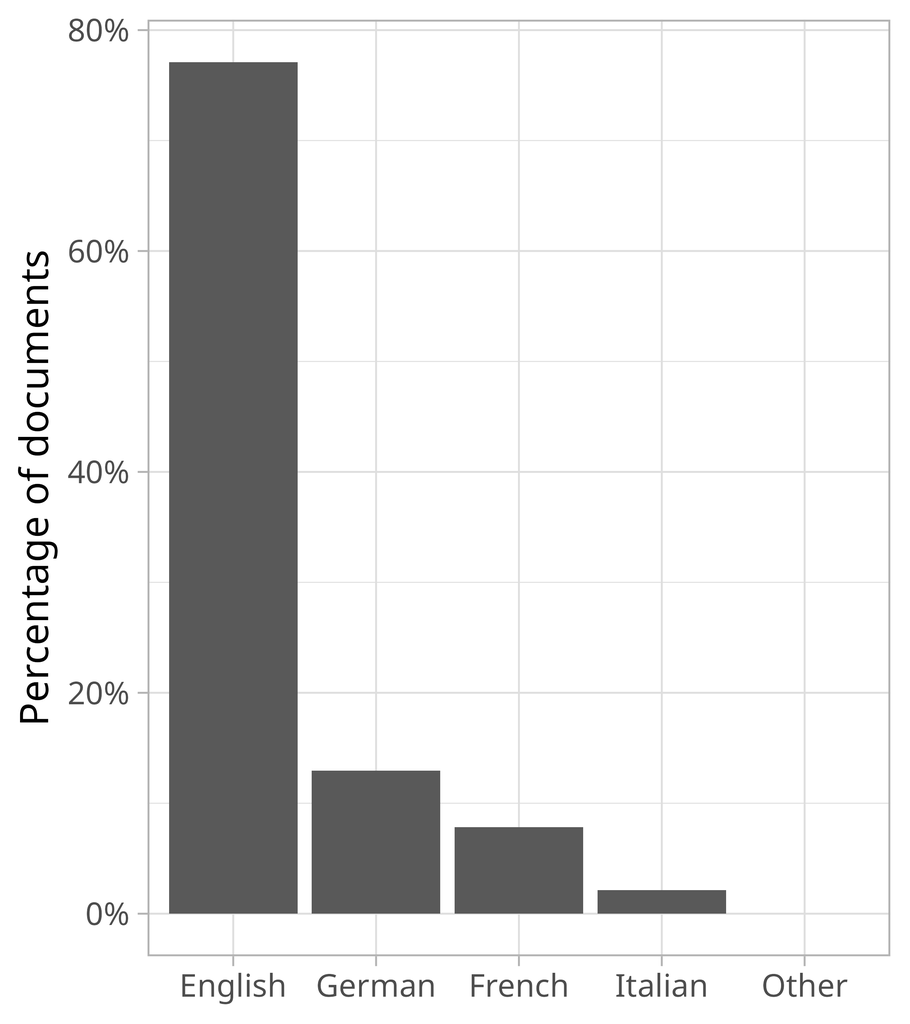

Figure 2: Exploration of the corpus with simple text analysis tools

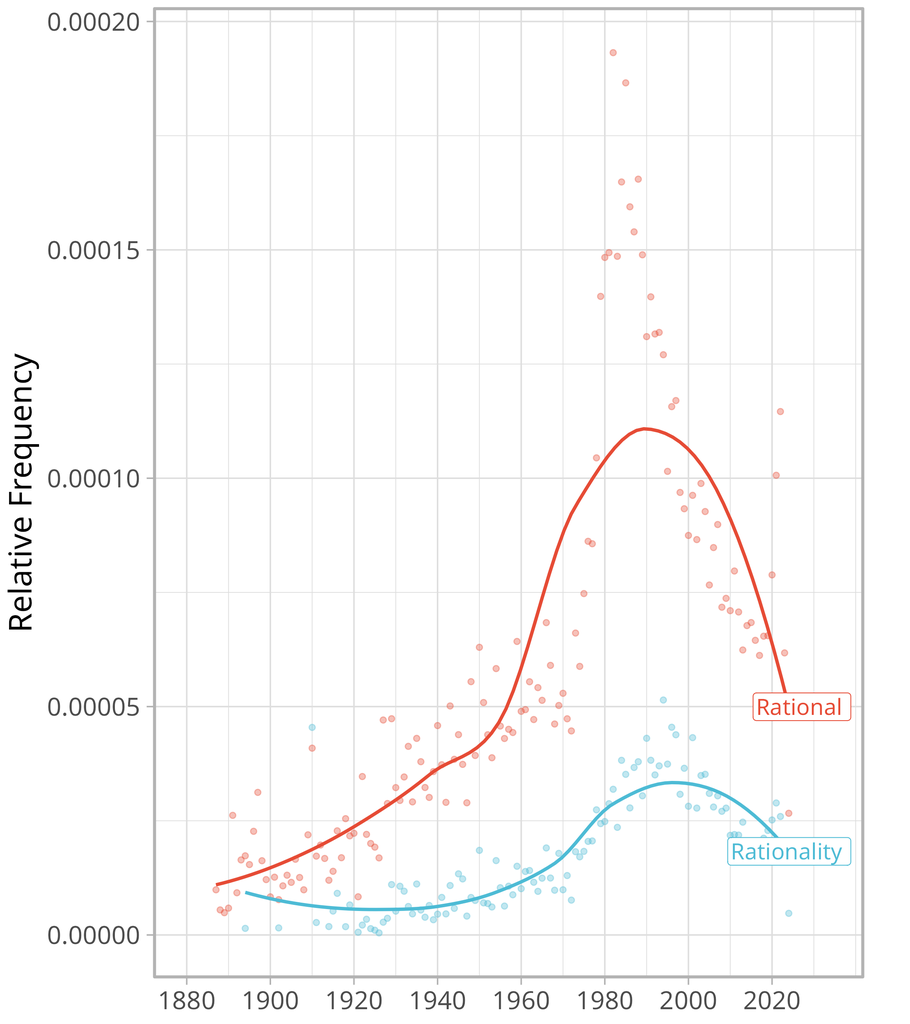

Neighbor words of “rational” and “rationality”

[figure not shown]

## Which computational methods?

Figure 3: Illustrations of common unsupervised methods in HET for large-scale analysis

Network and bibliometric analysis

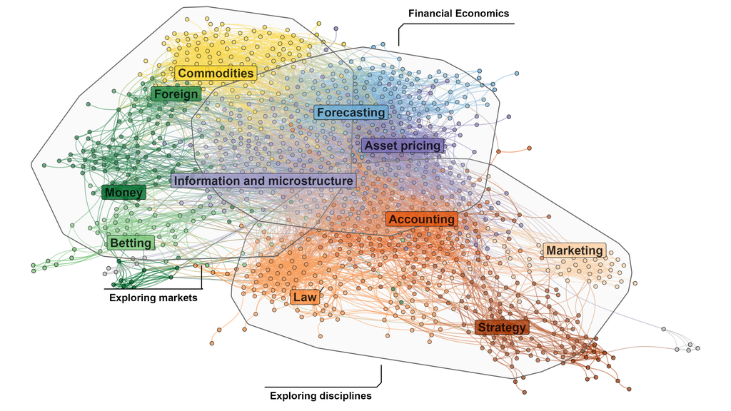

Probablistic topic model

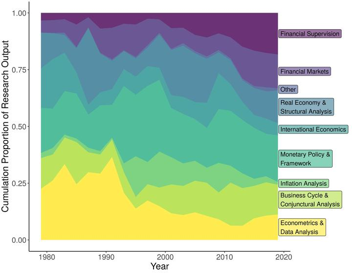

## Introducing LLMs to HET

Figure 4: A simplified representation of words embeddings in 2D

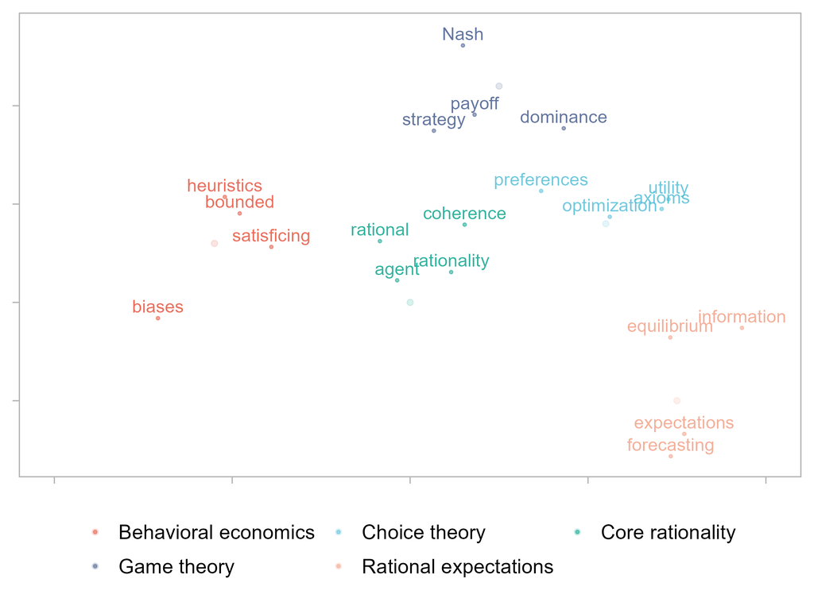

LLMs: Each unique word are represented as vectors.

The distance between vectors reflects semantic similarity.

## Sentence embeddings

We use sentence-BERT, a fast LLM model that reprensents **sentences** as vectors and is optimized for semantic similarity tasks.

Table 1: Closest to ‘Economic agents are supposed to be rational.’

| year | sentence | similarity |
| --- | --- | --- |
| 1950 | Basically, for Professor Hicks, as for Jevons and Marshall, economic decisions are made by an abstract calculating machine. | 0.706 |
| 1950 | Modern civilization is lopsided in its emphasis on rationality, especially on economic rationality. | 0.700 |
| 1950 | Rational behavior means conduct motivated by the goal of maximization of money income, wealth and economic advantages. | 0.700 |
| 1975 | Rationality and Irrationality in Economics. | 0.750 |
| 1975 | Such agents are assumed to act rationally and exclusively on the basis of market given information. | 0.721 |
| 1975 | In Marshallian analysis, economic agents are conceived to be not so much rational as reasonable. | 0.710 |
| 2000 | Agents have rational expectations. | 0.771 |
| 2000 | Rational in the narrow economic sense of profit maximizing. | 0.768 |
| 2000 | Actors who operate in an economy are generally rational in the sense that they are interested in improving their individual position. | 0.768 |

**Our empirical strategy:**

1. Compute a “representative vectors” for the concept of rationality.
2. Retrieve the most similar sentences in the corpus from this vector.
3. Group those sentences into clusters.

[figure not shown]

## Navigating our own results with an app

https://0199205a-7b17-ab11-595d-8f12aae160dd.share.connect.posit.cloud/

## Conclusion

- LLMs offers a tool to quantify conceptual relationship betweens texts.

**But important challenges:**

- Existing models are trained for understanding general language, not economic discourses.
- Model are present-centric.
- Computational ressources.
- Data access (Elsevier, Taylor and Francis, Books, *etc*.).